# C42B cells mono and bi-therapies : bulkRNAseq summary

Marion Hardy

2026-01-05

# Introduction

BulkRNAseq analysis of C42B cells treated with mono or bi-therapies.

This report will present a broad overview of how similar/different samples are in terms of gene expression. The objective is to help AK narrow down which gene sets are of interest and follow this with a gsea analysis and a closer look at the function of these identified gene groups.

Each sample comparison shown in this report will have additional files generated:

- res_tbl.csv = all differentially expressed genes, annotated (no filtering)
- Sign_genes.xlsx = excel doc with all significantly up- and down-regulated genes (log2Fc >= 1), annotated and sorted into all genes, only up and only down on different sheets.
- volcano plot of all genes (html format)

NB: Data quality has been checked within the previous script “DESeq2.R”, everything looked good.

# PCA

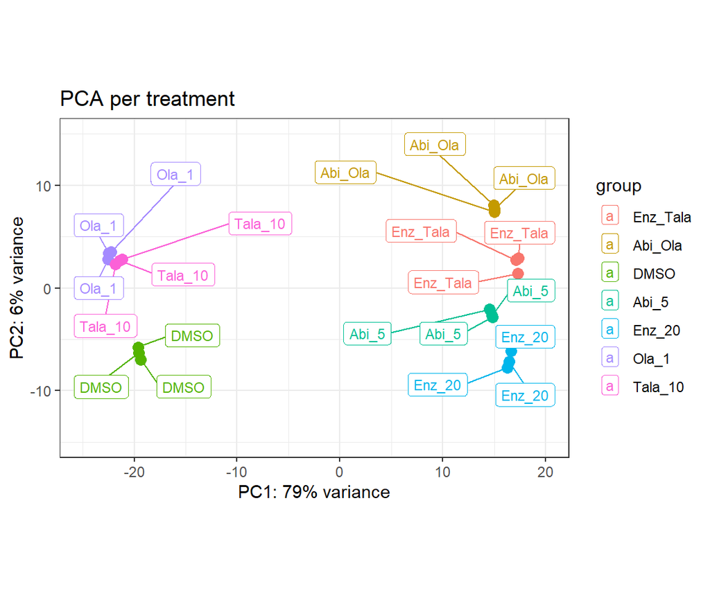

# Every treatment compared to DMSO

## Volcano plots

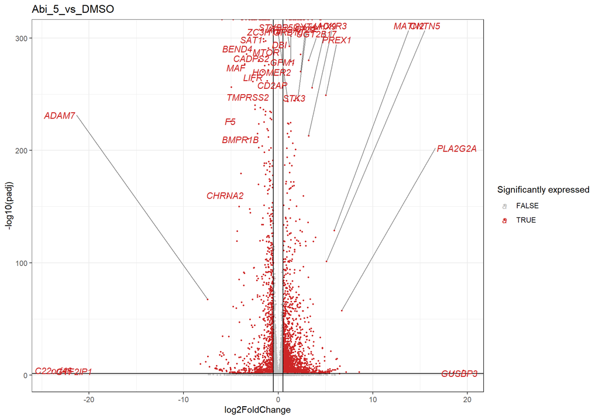

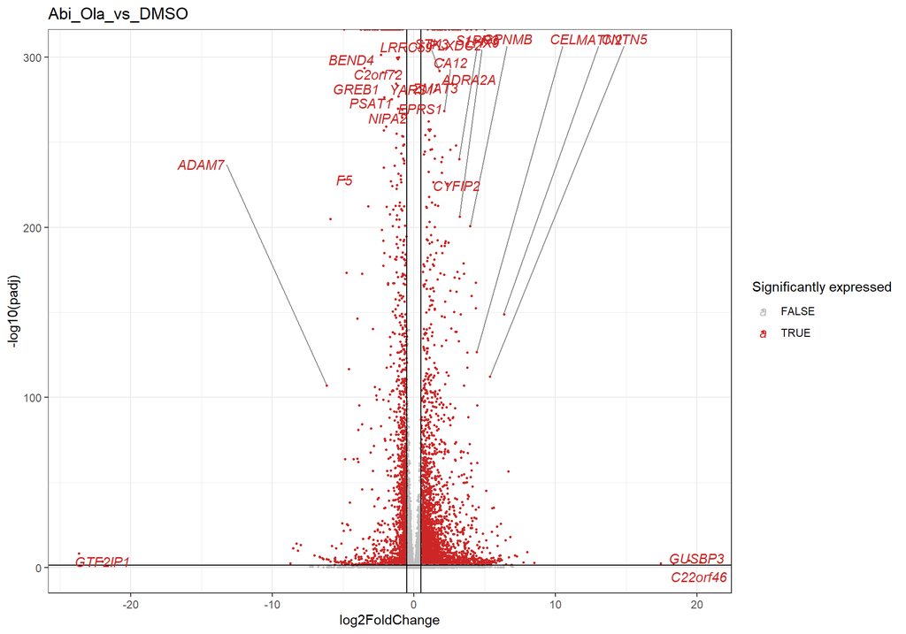

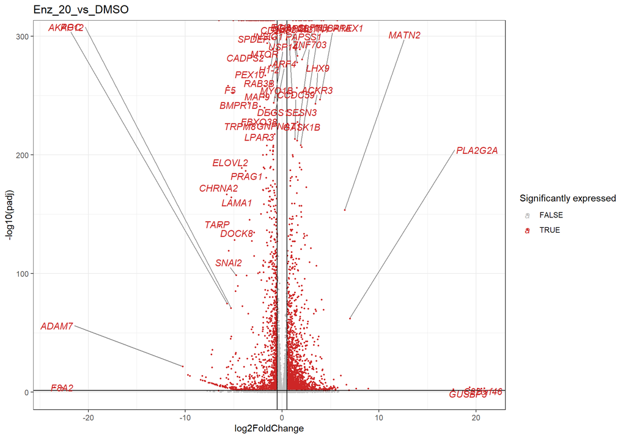

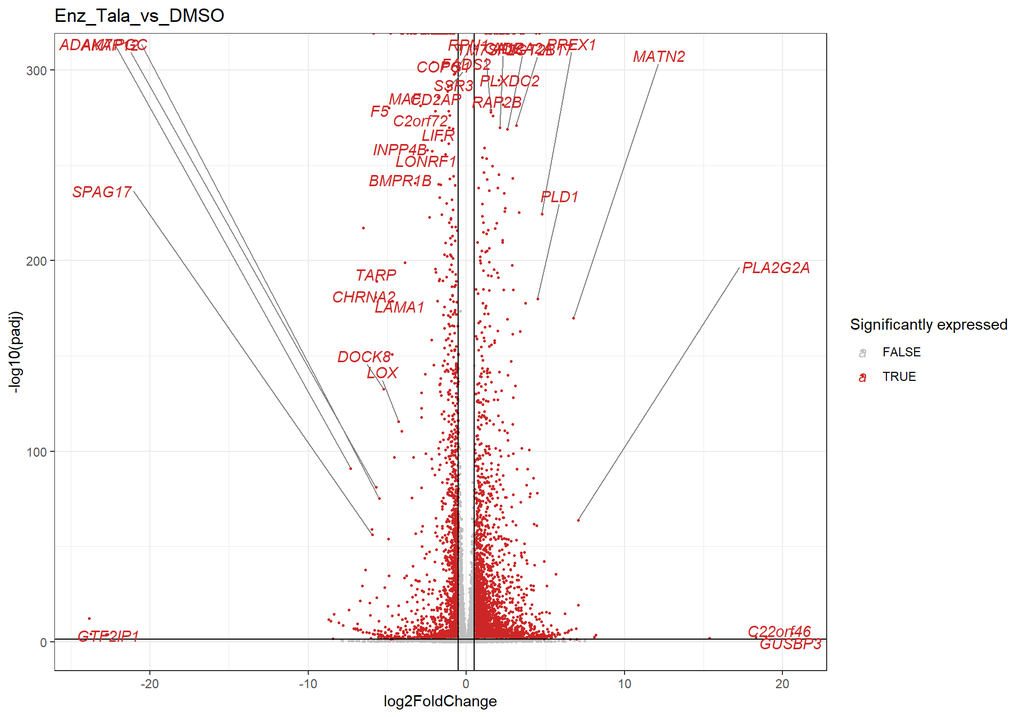

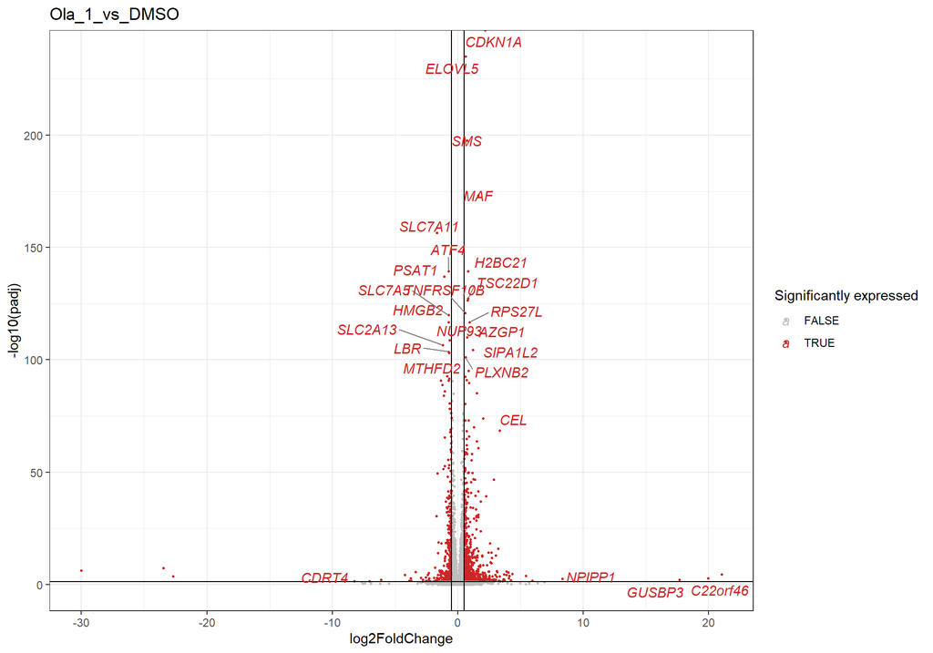

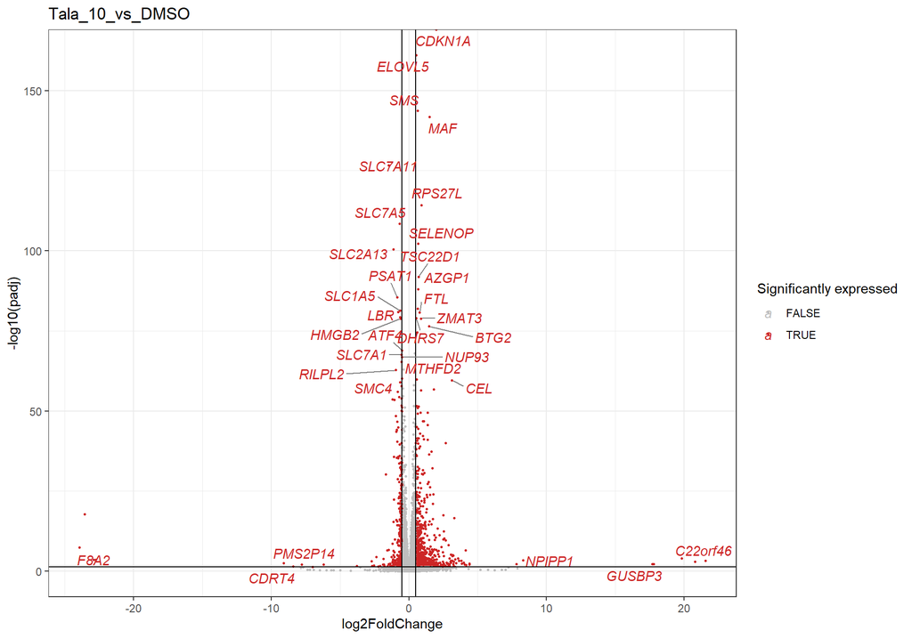